# Exploratory Graphs

## Hierarchical clustering

Organizes things that are **close** into groups produces dendrogram

How do we define close?

- most important step
  - Garbage in -> garbage out: if we use a garbage variable, we'll produce garbage clustering

Euclidean distance

- Used for quantitative - continuous vairables

Manhattan distance

- distance on a grid (?)

example

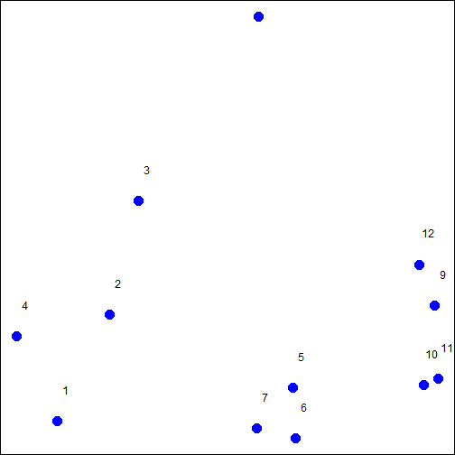

```r
set.seed(1234)
par(mar = c(0, 0, 0, 0))
x <- rnorm(12, mean = rep(1:3, each = 4), sd = 0.2)
y <- rnorm(12, mean = rep(1, 2, 1, each = 4), sd = 0.2)
plot(x, y, col = "blue", pch = 19, cex = 2)
text(x + 0.05, y + 0.05, labels = as.character(1:12))
```

dist

```r
dataFrame <- data.frame(x = x, y = y)
dist(dataFrame)
```

```
##          1       2       3       4       5       6       7       8       9
## 2  0.34121
## 3  0.57494 0.24103
## 4  0.26382 0.52579 0.71862
## 5  1.32830 1.03675 0.91736 1.55703
## 6  1.34290 1.06378 0.96021 1.57850 0.08150
## 7  1.12653 0.84894 0.75866 1.36197 0.21110 0.21667
## 8  1.29969 0.95849 0.73405 1.45064 0.61704 0.69792 0.65063
## 9  2.13630 1.83168 1.67836 2.35676 0.81161 0.81323 1.02071 1.09597
## 10 2.06420 1.76999 1.63110 2.29239 0.73618 0.72567 0.93950 1.09785 0.14090
## 11 2.14702 1.85183 1.71074 2.37462 0.81886 0.80885 1.02259 1.16375 0.11624
## 12 2.05664 1.74663 1.58659 2.27232 0.74040 0.75095 0.95131 0.99022 0.10849
##         10      11
## 2
## 3
## 4
## 5
## 6
## 7
## 8
## 9
## 10
## 11 0.08318
## 12 0.19129 0.20803
```

#1 closest 2 points get picked, and merged, and so forth until we have 1 point left

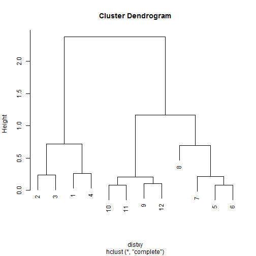

```r
distxy <- dist(dataFrame)
hClustering <- hclust(distxy)
plot(hClustering)
```

To decide clusters things get broken into, we have to cut the dendrogram at some point.

#### Prettier dendrograms

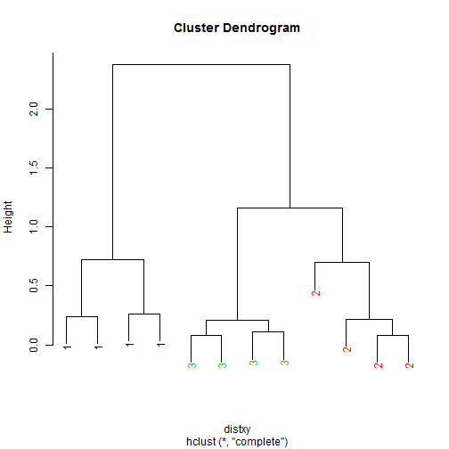

```r
myplclust <- function(hclust, lab = hclust$labels, lab.col = rep(1, length(hclust$labels)),
    hang = 0.1, ...) {
    y <- rep(hclust$height, 2)
    x <- as.numeric(hclust$merge)
    y <- y[which(x < 0)]
    x <- x[which(x < 0)]
    x <- abs(x)
    y <- y[order(x)]
    x <- x[order(x)]
    plot(hclust, labels = F, hang = hang, ...)
    text(x = x, y = y[hclust$order] - (max(hclust$height) * hang), labels = lab[hclust$order],
        col = lab.col[hclust$order], srt = 90, adj = c(1, 0.5), xpd = NA, ...)
}
dataFrame <- data.frame(x = x, y = y)
distxy <- dist(dataFrame)
hClustering <- hclust(distxy)
myplclust(hClustering, lab = rep(1:3, each = 4), lab.col = rep(1:3, each = 4))
```

graph 79 on R Graph Gallery

Merging points:

- complete
  - Complete linkage - comparing points farthest apart
- average
  - uses average distance

#### heatmap()

visualizing quantitative data after they were clustered

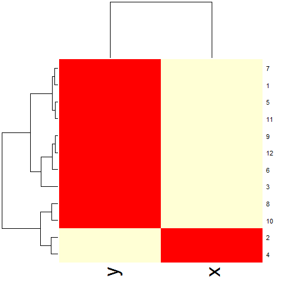

```r
df <- data.frame(x = x, y = y)
set.seed(143)
dataMatrix <- as.matrix(dataFrame)[sample(1:12), ]
heatmap(dataMatrix)
```

# K-Means Clustering

Continuous - Euclidian distance is usually used in k-means clustering.

When determining a reasonable number of clusters, pick a large one, then go down.

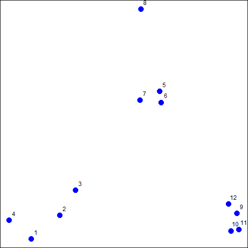

```r
set.seed(1234)
par(mar = c(0, 0, 0, 0))
x <- rnorm(12, mean = rep(1:3, each = 4), sd = 0.2)
y <- rnorm(12, mean = rep(c(1, 2, 1), each = 4), sd = 0.2)
plot(x, y, col = "blue", pch = 19, cex = 2)
text(x + 0.05, y + 0.05, labels = as.character(1:12))
```

#### Starting centroids

1. Assign all the points to the closer centroid
2. Recalculate centroids by taking the euclidian distance between each of the points
3. Reassign points to centroids
4. Iterate

`kmeans()`

- params:
  - x - data frame or matrix
  - centers - number of centers
  - iter.max - for large datasets not to run forever
  - nstart - number of starting points - kmeans is non-deterministic, you can restart multiple times and get an average cluster over those starts

```r
dataFrame <- data.frame(x, y)
kmeansObj <- kmeans(dataFrame, centers = 3)
names(kmeansObj)
```

```
## [1] "cluster"      "centers"      "totss"        "withinss"
## [5] "tot.withinss" "betweenss"    "size"
```

```r
kmeansObj$cluster
```

```
##  [1] 3 3 3 3 1 1 1 1 2 2 2 2
```

#### Plot clusters

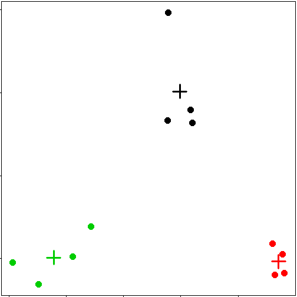

```r
par(mar = rep(0.2, 4))
plot(x, y, col = kmeansObj$cluster, pch = 19, cex = 2)
points(kmeansObj$centers, col = 1:3, pch = 3, cex = 3, lwd = 3)
```

#### With heatmaps

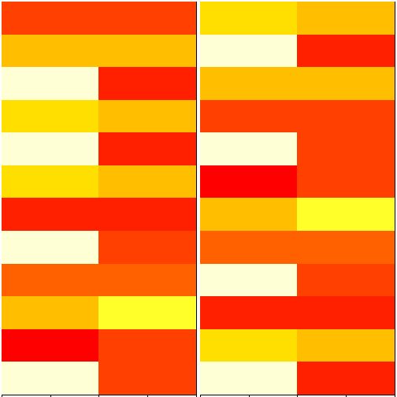

```r
set.seed(1234)
dataMatrix <- as.matrix(dataFrame)[sample(1:12), ]
kmeansObj2 <- kmeans(dataMatrix, centers = 3)
par(mfrow = c(1, 2), mar = rep(0.2, 4))
image(t(dataMatrix)[, nrow(dataMatrix):1], yaxt = "n")
image(t(dataMatrix)[, order(kmeansObj$cluster)], yaxt = "n")
```

Scrambled and unscrambled heatmaps - col1: x, col2: y

# Principal components analysis and singular value decomposition

Compress large set of variables into a smaller one

## Matrix data

No relation between variables and observation column: variable row: observation

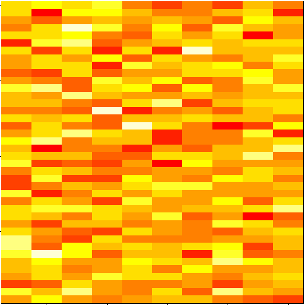

```r
set.seed(12345)
par(mar = rep(0.2, 4))
dataMatrix <- matrix(rnorm(400), nrow = 40)
image(1:10, 1:40, t(dataMatrix)[, nrow(dataMatrix):1])
```

You can confirm there are no patterns with dendrogram

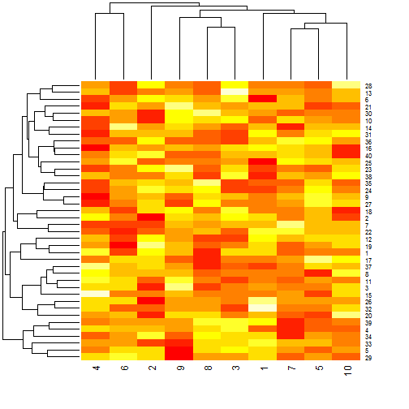

```r
par(mar = rep(0.2, 4))
heatmap(dataMatrix)
```

We can add a pattern that affects some rows

```r
# for each row
for (i in 1:40) {
    # flip a coin
    coinFlip <- rbinom(1, size = 1, prob = 0.5)
    # if coin is heads add a common pattern to that row
    if (coinFlip) {
        # pattern: first 5 variables are 0, last 5 are 3
        dataMatrix[i, ] <- dataMatrix[i, ] + rep(c(0, 3), each = 5)
    }
}
```

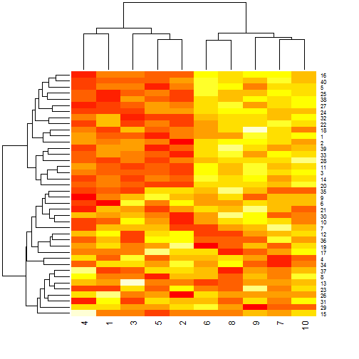

```r
par(mar = rep(0.2, 4))
heatmap(dataMatrix)
```

To find the patterns without looking at the entire data set we can:

1. take the means of rows and columns

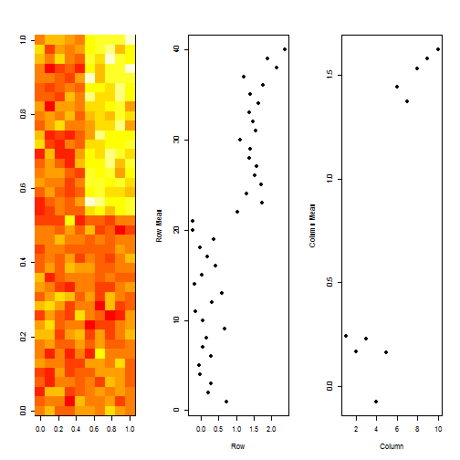

```r
hh <- hclust(dist(dataMatrix))
dataMatrixOrdered <- dataMatrix[hh$order, ]
par(mfrow = c(1, 3))
image(t(dataMatrixOrdered)[, nrow(dataMatrixOrdered):1])
plot(rowMeans(dataMatrixOrdered), 40:1, , xlab = "Row", ylab = "Row Mean", pch = 19)
plot(colMeans(dataMatrixOrdered), xlab = "Column", ylab = "Column Mean", pch = 19)
```

In figure 2 mean of each row is plotted, we can see hihger values cluster on the top right.

What happens if there's more than one pattern?

## SVD

#### Components: v

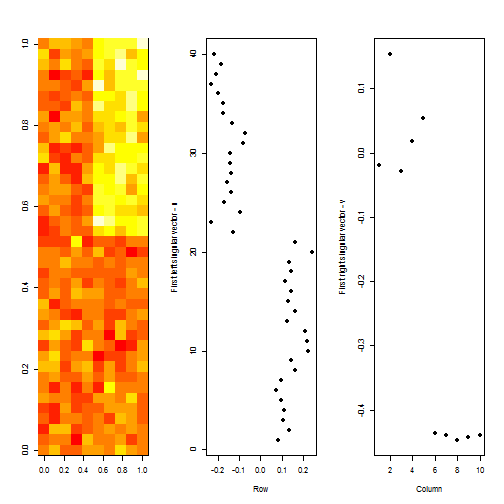

```r
svd1 <- svd(scale(dataMatrixOrdered))
par(mfrow = c(1, 3))
image(t(dataMatrixOrdered)[, nrow(dataMatrixOrdered):1])
plot(svd1$u[, 1], 40:1, , xlab = "Row", ylab = "First left singular vector - u",
    pch = 19)
plot(svd1$v[, 1], xlab = "Column", ylab = "First right singular vector - v",
    pch = 19)
```

Looking at v - the 5 values at the bottom right make sense because last 5 columns all have a particular value, unlike first 5.

#### Components: d and variance

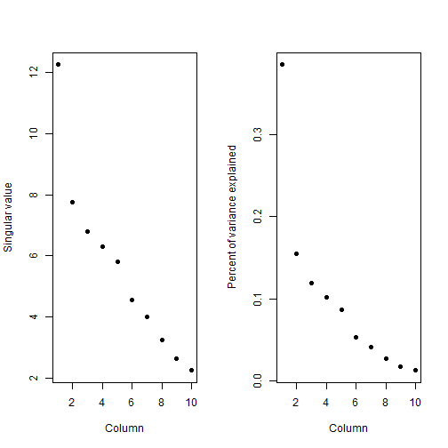

```r
svd1 <- svd(scale(dataMatrixOrdered))
par(mfrow = c(1, 2))
plot(svd1$d, xlab = "Column", ylab = "Singular value", pch = 19)
plot(svd1$d^2/sum(svd1$d^2), xlab = "Column", ylab = "Percent of variance explained",
    pch = 19)
```

The decreasing set of values in the first figure start with first left singular vector, then second, etc.

Figure 2 - first point explains 40 percent of the variance, etc. What people do is to add up the cumulative amounts of variance explained moving from left to right and identify patterns that explain some large percentage of the variance, 80, 90%. They can then compress the data by only considering components of SVD that represent those patterns.

## Relationship to PCA

Taking first PC vs first right singular vector, they're the same

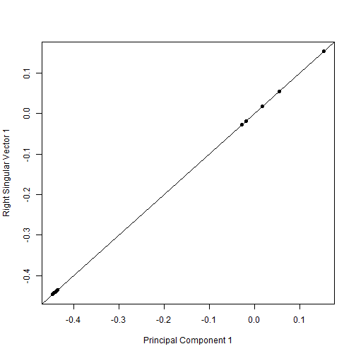

```r
svd1 <- svd(scale(dataMatrixOrdered))
pca1 <- prcomp(dataMatrixOrdered, scale = T)
plot(pca1$rotation[, 1], svd1$v[, 1], pch = 19, xlab = "Principal Component 1",
    ylab = "Right Singular Vector 1")
abline(c(0, 1))
```

## Components of the SVD - variance explained

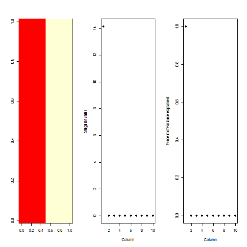

```r
constantMatrix <- dataMatrixOrdered * 0
for (i in 1:dim(dataMatrixOrdered)[1]) {
    # matrix where every row is the same
    constantMatrix[i, ] <- rep(c(0, 1), each = 5)
}
svd1 <- svd(constantMatrix)
par(mfrow = c(1, 3))
image(t(constantMatrix)[, nrow(constantMatrix):1])
plot(svd1$d, xlab = "Column", ylab = "Singular value", pch = 19)
plot(svd1$d^2/sum(svd1$d^2), xlab = "Column", ylab = "Percent of variance explained",
    pch = 19)
```

100% of the variance is explained by the first d value. Reason is that if we take u and v and multiply them together, we can reproduce the matrix exactly, so all the variation in the matrix is explained by one pattern.

If the data was random, each singular vector would explain approximately 1/the number of columns variance in the data set.

## What if we add a second pattern?

```r
set.seed(678910)
for (i in 1:40) {
    # flip a coin
    coinFlip1 <- rbinom(1, size = 1, prob = 0.5)
    coinFlip2 <- rbinom(1, size = 1, prob = 0.5)

    # if coin is heads, add a common pattern to that row
    if (coinFlip1) {
        dataMatrix[i, ] <- dataMatrix[i, ] + rep(c(0, 5), each = 5)
    }
    if (coinFlip2) {
        dataMatrix[i, ] <- dataMatrix[i, ] + rep(c(0, 5), 5)
    }
}
hh <- hclust(dist(dataMatrix))
dataMatrixOrdered <- dataMatrix[hh$order, ]
```

Now cluster the data set and plot

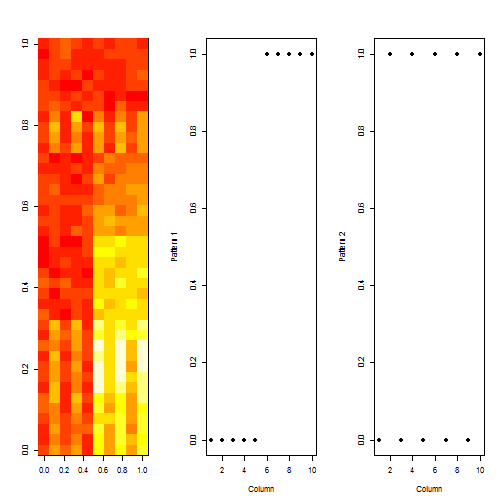

```r
svd2 <- svd(scale(dataMatrixOrdered))
par(mfrow = c(1, 3))
image(t(dataMatrixOrdered)[, nrow(dataMatrixOrdered):1])
plot(rep(c(0, 1), each = 5), xlab = "Column", ylab = "Pattern 1", pch = 19)
plot(rep(c(0, 1), 5), xlab = "Column", ylab = "Pattern 2", pch = 19)
```

We can see that there are 2 patterns in the data set:

- values high on right hand side and low on left hand side
- stripes - low - high - low - high

The two patterns overlap each other

In the second plot, we can see Pattern 1 is low for first 5 columns then high for next 5. Pattern 2 is flip/flopping.

## v and patterns of variance in rows

svd2 <- svd(scale(dataMatrixOrdered))

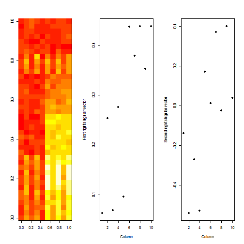

```r
par(mfrow = c(1, 3))
image(t(dataMatrixOrdered)[, nrow(dataMatrixOrdered):1])
plot(svd2$v[, 1], xlab = "Column", ylab = "First right singular vector", pch = 19)
plot(svd2$v[, 2], xlab = "Column", ylab = "Second right singular vector", pch = 19)
```

The first figure flip flops low/high, but also first 5 values are lower than second 5. In second figure, the patterns are flipped. Together they explain most of the variation in the matrix.

## d and variance explained

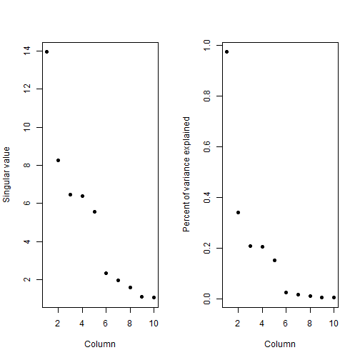

```r
svd2 <- svd(scale(dataMatrixOrdered))
par(mfrow = c(1, 2))
plot(svd2$d, xlab = "Column", ylab = "Singular value", pch = 19)
plot(svd2$d^2/sum(svd1$d^2), xlab = "Column", ylab = "Percent of variance explained",
    pch = 19)
```

We can see that first and second values explain most of the variance. This would suggest that there are two patterns in the data set but they aren't necessarily the two patterns we observed in singular vectors. Each of the singular vectors may represent multiple patterns mashed together.

## fast.svd function {corpcor}

- params: m, tol

```r
bigMatrix <- matrix(rnorm(10000 * 40), nrow = 10000)
system.time(svd(scale(bigMatrix)))
```

```
##    user  system elapsed
##    0.29    0.02    0.43
```

```r
library(corpcor)
# fast.svd only calculates singular values/vectors for values above the
# tolerance, this way it calculates all
system.time(fast.svd(scale(bigMatrix), tol = 0))
```

```
##    user  system elapsed
##    0.22    0.05    0.27
```

## Missing values

SVD cannot be performed on missing values, 19/25. One option is to impute those values

## Imputing {impute}

```
source("http://bioconductor.org/biocLite.R")
biocLite("impute")
then install from directory
to cite: citation("impute")
```

There's a bunch of ways but for exploratory analysis use impute package. knn approach

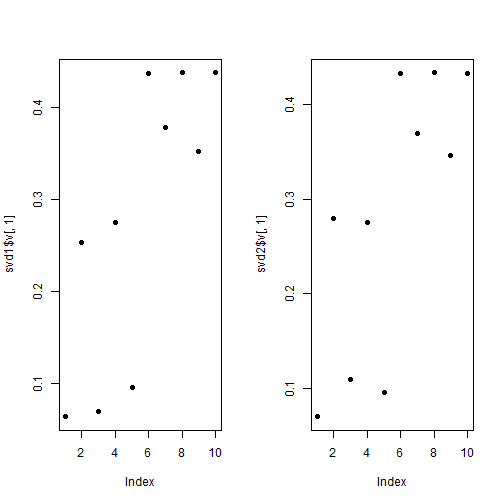

```r
library(impute)
dataMatrix2 <- dataMatrixOrdered
dataMatrix2[sample(1:100, size = 40, replace = F)] <- NA
dataMatrix2 <- impute.knn(dataMatrix2)$data
svd1 <- svd(scale(dataMatrixOrdered))
svd2 <- svd(scale(dataMatrix2))
par(mfrow = c(1, 2))
plot(svd1$v[, 1], pch = 19)
plot(svd2$v[, 1], pch = 19)
```

Compared to the complete data set, they're very similar, however if the dataset is missing a large number of data, it may not always work.

## Face example

21/25 Advanced data analysis from an elementary point of view Elements of statistical learning